# Homework 4: Machine Learning

## 3.2 Categorical variables

Write a paragraph discussing the output of the following

IK: It appears that there is a substantial variation in the proportion of the failed tests across movies ganres. Thus, action movies fail the test in more than 70% of the sample (the highest rate) while comedy movies fail only in 42.7% cases (the lowest rate). The same is true for movie ratings. There seems to be more test values for G rated movies compared to all others except for NC-17 movies. However, NC-17 movie variation is not reliable because of very few observations in this category.

```r
bechdel %>%
  group_by(genre, test) %>%
  summarise(n = n()) %>%
  mutate(prop = n/sum(n))
```

```
## # A tibble: 24 × 4
## # Groups:   genre [14]
##    genre     test      n  prop
##    <chr>     <fct> <int> <dbl>
##  1 Action    Fail    260 0.707
##  2 Action    Pass    108 0.293
##  3 Adventure Fail     52 0.559
##  4 Adventure Pass     41 0.441
##  5 Animation Fail     63 0.677
##  6 Animation Pass     30 0.323
##  7 Biography Fail     36 0.554
##  8 Biography Pass     29 0.446
##  9 Comedy    Fail    138 0.427
## 10 Comedy    Pass    185 0.573
## # ℹ 14 more rows
```

```r
bechdel %>%
  group_by(rated, test) %>%
  summarise(n = n()) %>%
  mutate(prop = n/sum(n))
```

```
## # A tibble: 10 × 4
## # Groups:   rated [5]
##    rated test      n  prop
##    <chr> <fct> <int> <dbl>
##  1 G     Fail     16 0.615
##  2 G     Pass     10 0.385
##  3 NC-17 Fail      5 0.833
##  4 NC-17 Pass      1 0.167
##  5 PG    Fail    115 0.561
##  6 PG    Pass     90 0.439
##  7 PG-13 Fail    283 0.529
##  8 PG-13 Pass    252 0.471
##  9 R     Fail    353 0.568
## 10 R     Pass    269 0.432
```

# 4 Train first models. `test ~ metascore + imdb_rating`

```r
lr_mod <- logistic_reg() %>%
  set_engine(engine = "glm") %>%
  set_mode("classification")

lr_mod
```

```
## Logistic Regression Model Specification (classification)
##
## Computational engine: glm
```

```r
tree_mod <- decision_tree() %>%
  set_engine(engine = "C5.0") %>%
  set_mode("classification")

tree_mod
```

```
## Decision Tree Model Specification (classification)
##
## Computational engine: C5.0
```

```r
lr_fit <- lr_mod %>% # parsnip model
  fit(test ~ metascore + imdb_rating, # a formula
    data = bechdel_train # dataframe
  )

tree_fit <- tree_mod %>% # parsnip model
  fit(test ~ metascore + imdb_rating, # a formula
    data = bechdel_train # dataframe
  )
```

## 4.1 Logistic regression

```r
lr_fit %>%
  broom::tidy()
```

```
## # A tibble: 3 × 5
##   term        estimate std.error statistic  p.value
##   <chr>          <dbl>     <dbl>     <dbl>    <dbl>
## 1 (Intercept)   2.80     0.494        5.68 1.35e- 8
## 2 metascore     0.0207   0.00536      3.86 1.13e- 4
## 3 imdb_rating  -0.625    0.100       -6.24 4.36e-10
```

```r
lr_preds <- lr_fit %>%
  augment(new_data = bechdel_train) %>%
  mutate(.pred_match = if_else(test == .pred_class, 1, 0))
```

### 4.1.1 Confusion matrix

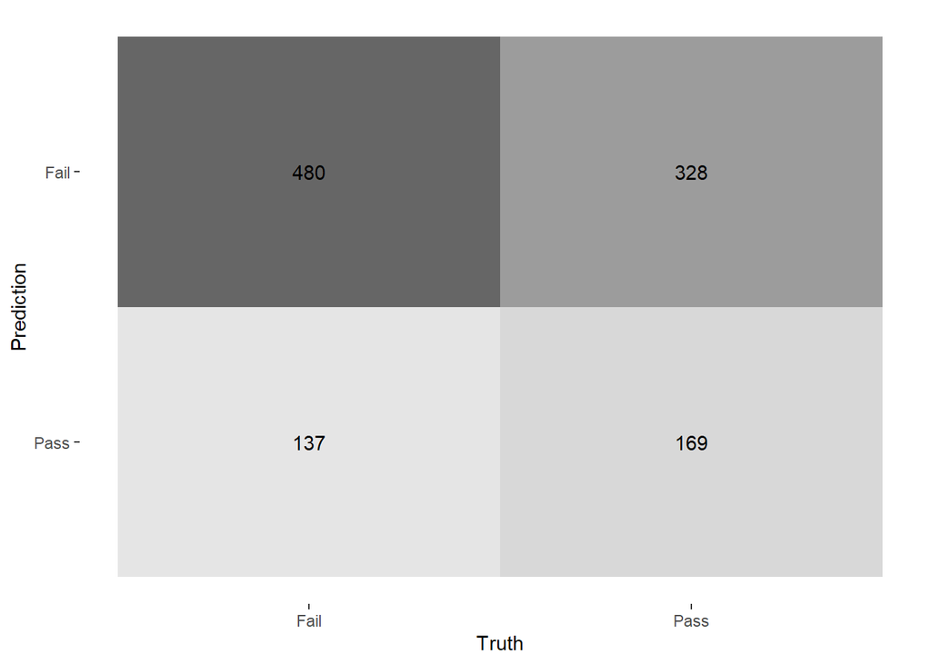

```r
lr_preds %>%
  conf_mat(truth = test, estimate = .pred_class) %>%
  autoplot(type = "heatmap")
```

## 4.2 Decision Tree

```r
tree_preds <- tree_fit %>%
  augment(new_data = bechdel) %>%
  mutate(.pred_match = if_else(test == .pred_class, 1, 0))
```

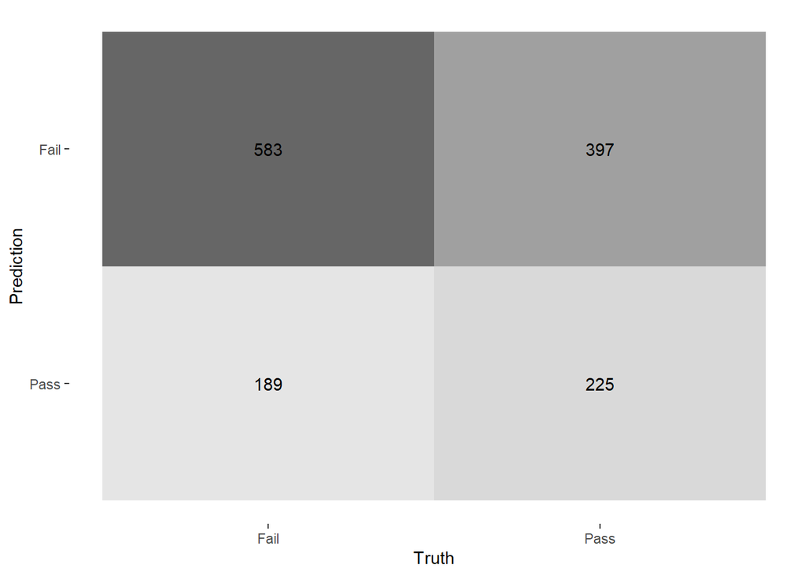

```r
tree_preds %>%
  conf_mat(truth = test, estimate = .pred_class) %>%
  autoplot(type = "heatmap")
```

## 4.3 Draw the decision tree

[figure not shown]

```r
draw_tree <-
    rpart::rpart(
        test ~ metascore + imdb_rating,
        data = bechdel_train, # uses data that contains both birth weight and `low`
        control = rpart::rpart.control(maxdepth = 5, cp = 0, minsplit = 10)
    ) %>%
    partykit::as.party()
plot(draw_tree)
```

# 5 Cross Validation

Run the code below. What does it return?

IK: it returns an object that divides training dataset bechdel_train into 10 folds for cross validation

```r
set.seed(123)
bechdel_folds <- vfold_cv(data = bechdel_train,
                          v = 10,
                          strata = test)
class(bechdel_folds)
```

```
## [1] "vfold_cv"   "rset"       "tbl_df"     "tbl"        "data.frame"
```

## 5.1 `fit_resamples()`

Trains and tests a resampled model.

```r
lr_fit <- lr_mod %>%
  fit_resamples(
    test ~ metascore + imdb_rating,
    resamples = bechdel_folds
  )


tree_fit <- tree_mod %>%
  fit_resamples(
    test ~ metascore + imdb_rating,
    resamples = bechdel_folds
  )
```

## 5.2 `collect_metrics()`

Unnest the metrics column from a tidymodels `fit_resamples()`

```r
collect_metrics(lr_fit)
```

```
## # A tibble: 2 × 6
##   .metric  .estimator  mean     n std_err .config
##   <chr>    <chr>      <dbl> <int>   <dbl> <chr>
## 1 accuracy binary     0.575    10  0.0149 Preprocessor1_Model1
## 2 roc_auc  binary     0.606    10  0.0189 Preprocessor1_Model1
```

```r
collect_metrics(tree_fit)
```

```
## # A tibble: 2 × 6
##   .metric  .estimator  mean     n std_err .config
##   <chr>    <chr>      <dbl> <int>   <dbl> <chr>
## 1 accuracy binary     0.571    10  0.0156 Preprocessor1_Model1
## 2 roc_auc  binary     0.547    10  0.0201 Preprocessor1_Model1
```

```r
tree_preds <- tree_mod %>%
  fit_resamples(
    test ~ metascore + imdb_rating,
    resamples = bechdel_folds,
    control = control_resamples(save_pred = TRUE) #<<
  )

# What does the data for ROC look like?
tree_preds %>%
  collect_predictions() %>%
  roc_curve(truth = test, .pred_Fail)
```

```
## # A tibble: 29 × 3
##    .threshold specificity sensitivity
##         <dbl>       <dbl>       <dbl>
##  1   -Inf         0             1
##  2      0.262     0             1
##  3      0.317     0.00201       0.989
##  4      0.373     0.00805       0.982
##  5      0.440     0.0181        0.976
##  6      0.459     0.0443        0.943
##  7      0.460     0.0765        0.924
##  8      0.464     0.115         0.901
##  9      0.465     0.147         0.887
## 10      0.465     0.191         0.864
## # ℹ 19 more rows
```

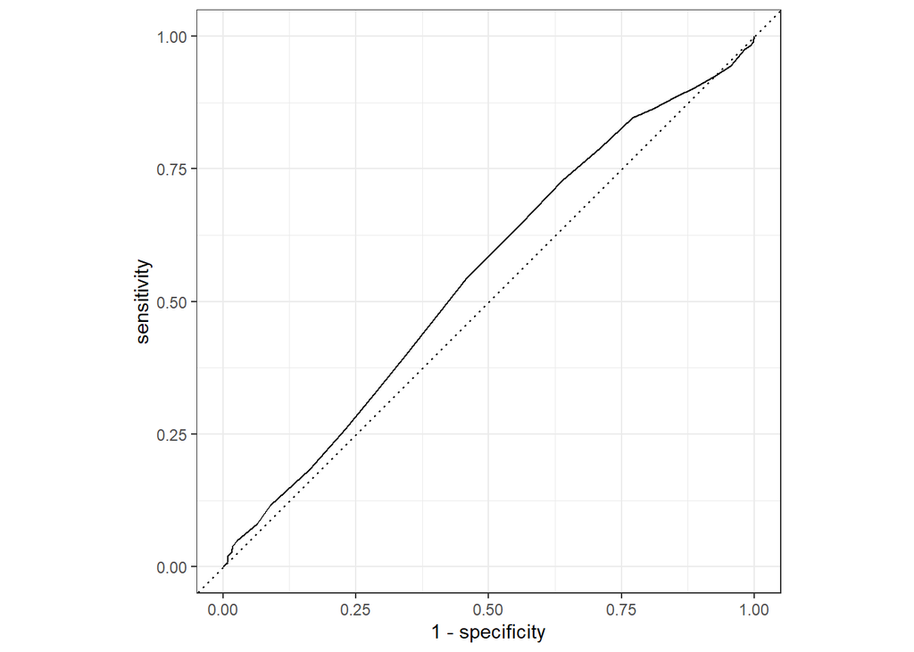

```r
# Draw the ROC
tree_preds %>%
  collect_predictions() %>%
  roc_curve(truth = test, .pred_Fail) %>%
  autoplot()
```

# 6 Build a better training set with `recipes`

## 6.1 Preprocessing options

- Encode categorical predictors
- Center and scale variables
- Handle class imbalance
- Impute missing data
- Perform dimensionality reduction
- … …

## 6.2 To build a recipe

1. Start the `recipe()`
2. Define the variables involved
3. Describe **prep**rocessing [step-by-step]

## 6.3 Collapse Some Categorical Levels

Do we have any `genre` with few observations? Assign genres that have less than 3% to a new category ‘Other’

[figure not shown]

```r
movie_rec <-
  recipe(test ~ .,
         data = bechdel_train) %>%

  # Genres with less than 5% will be in a catewgory 'Other'
    step_other(genre, threshold = .03)
```

## 6.4 Before recipe

```
## # A tibble: 14 × 2
##    genre           n
##    <chr>       <int>
##  1 Action        293
##  2 Comedy        254
##  3 Drama         213
##  4 Adventure      75
##  5 Animation      72
##  6 Crime          68
##  7 Horror         68
##  8 Biography      50
##  9 Mystery         7
## 10 Fantasy         5
## 11 Sci-Fi          3
## 12 Thriller        3
## 13 Documentary     2
## 14 Musical         1
```

## 6.5 After recipe

```r
movie_rec %>%
  prep() %>%
  bake(new_data = bechdel_train) %>%
  count(genre, sort = TRUE)
```

```
## # A tibble: 9 × 2
##   genre         n
##   <fct>     <int>
## 1 Action      293
## 2 Comedy      254
## 3 Drama       213
## 4 Adventure    75
## 5 Animation    72
## 6 Crime        68
## 7 Horror       68
## 8 Biography    50
## 9 other        21
```

## 6.6 `step_dummy()`

Converts nominal data into numeric dummy variables

```r
movie_rec <- recipe(test ~ ., data = bechdel) %>%
  step_other(genre, threshold = .03) %>%
  step_dummy(all_nominal_predictors())

movie_rec
```

```
## ── Recipe ──────────────────────────────────────────────────────────────────────
```

```
## ── Inputs
```

```
## Number of variables by role
```

```
## outcome:   1
## predictor: 9
```

```
## ── Operations
```

```
## • Collapsing factor levels for: genre
```

```
## • Dummy variables from: all_nominal_predictors()
```

## 6.7 Let’s think about the modelling

What if there were no films with `rated` NC-17 in the training data?

- Will the model have a coefficient for `rated` NC-17?

IK: it will not have a coefficient. It depends on the alorithm but most likely it would be dropped as it would have a perfect colliniarity with the default group.

- What will happen if the test data includes a film with `rated` NC-17?

IK: this information would not be used to predict the test. It would have the same effect as being in the default category.

## 6.8 `step_novel()`

Adds a catch-all level to a factor for any new values not encountered in model training, which lets R intelligently predict new levels in the test set.

```r
movie_rec <- recipe(test ~ ., data = bechdel) %>%
  step_other(genre, threshold = .03) %>%
  step_novel(all_nominal_predictors) %>% # Use *before* `step_dummy()` so new level is dummified
  step_dummy(all_nominal_predictors())
```

## 6.9 `step_zv()`

Intelligently handles zero variance variables (variables that contain only a single value)

```r
movie_rec <- recipe(test ~ ., data = bechdel) %>%
  step_other(genre, threshold = .03) %>%
  step_novel(all_nominal(), -all_outcomes()) %>% # Use *before* `step_dummy()` so new level is dummified
  step_dummy(all_nominal(), -all_outcomes()) %>%
  step_zv(all_numeric(), -all_outcomes())
```

## 6.10 `step_normalize()`

Centers then scales numeric variable (mean = 0, sd = 1)

```r
movie_rec <- recipe(test ~ ., data = bechdel) %>%
  step_other(genre, threshold = .03) %>%
  step_novel(all_nominal(), -all_outcomes()) %>% # Use *before* `step_dummy()` so new level is dummified
  step_dummy(all_nominal(), -all_outcomes()) %>%
  step_zv(all_numeric(), -all_outcomes())  %>%
  step_normalize(all_numeric())
```

## 6.11 `step_corr()`

Removes highly correlated variables

```r
movie_rec <- recipe(test ~ ., data = bechdel) %>%
  step_other(genre, threshold = .03) %>%
  step_novel(all_nominal(), -all_outcomes()) %>% # Use *before* `step_dummy()` so new level is dummified
  step_dummy(all_nominal(), -all_outcomes()) %>%
  step_zv(all_numeric(), -all_outcomes())  %>%
  step_normalize(all_numeric()) %>%
  step_corr(all_predictors(), threshold = 0.75, method = "spearman")



movie_rec
```

```
## ── Recipe ──────────────────────────────────────────────────────────────────────
```

```
## ── Inputs
```

```
## Number of variables by role
```

```
## outcome:   1
## predictor: 9
```

```
## ── Operations
```

```
## • Collapsing factor levels for: genre
```

```
## • Novel factor level assignment for: all_nominal(), -all_outcomes()
```

```
## • Dummy variables from: all_nominal(), -all_outcomes()
```

```
## • Zero variance filter on: all_numeric(), -all_outcomes()
```

```
## • Centering and scaling for: all_numeric()
```

```
## • Correlation filter on: all_predictors()
```

# 7 Define different models to fit

```r
## Model Building

# 1. Pick a `model type`
# 2. set the `engine`
# 3. Set the `mode`: regression or classification

# Logistic regression
log_spec <-  logistic_reg() %>%  # model type
  set_engine(engine = "glm") %>%  # model engine
  set_mode("classification") # model mode

# Show your model specification
log_spec
```

```
## Logistic Regression Model Specification (classification)
##
## Computational engine: glm
```

```r
# Decision Tree
tree_spec <- decision_tree() %>%
  set_engine(engine = "C5.0") %>%
  set_mode("classification")

tree_spec
```

```
## Decision Tree Model Specification (classification)
##
## Computational engine: C5.0
```

```r
# Random Forest
library(ranger)

rf_spec <-
  rand_forest() %>%
  set_engine("ranger", importance = "impurity") %>%
  set_mode("classification")


# Boosted tree (XGBoost)
library(xgboost)
xgb_spec <-
  boost_tree() %>%
  set_engine("xgboost") %>%
  set_mode("classification")

# K-nearest neighbour (k-NN)
knn_spec <-
  nearest_neighbor(neighbors = 4) %>% # we can adjust the number of neighbors
  set_engine("kknn") %>%
  set_mode("classification")
```

# 8 Bundle recipe and model with `workflows`

```r
log_wflow <- # new workflow object
 workflow() %>% # use workflow function
 add_recipe(movie_rec) %>%   # use the new recipe
 add_model(log_spec)   # add your model spec

# show object
log_wflow
```

```
## ══ Workflow ════════════════════════════════════════════════════════════════════
## Preprocessor: Recipe
## Model: logistic_reg()
##
## ── Preprocessor ────────────────────────────────────────────────────────────────
## 6 Recipe Steps
##
## • step_other()
## • step_novel()
## • step_dummy()
## • step_zv()
## • step_normalize()
## • step_corr()
##
## ── Model ───────────────────────────────────────────────────────────────────────
## Logistic Regression Model Specification (classification)
##
## Computational engine: glm
```

```r
## A few more workflows

tree_wflow <-
 workflow() %>%
 add_recipe(movie_rec) %>%
 add_model(tree_spec)

rf_wflow <-
 workflow() %>%
 add_recipe(movie_rec) %>%
 add_model(rf_spec)

xgb_wflow <-
 workflow() %>%
 add_recipe(movie_rec) %>%
 add_model(xgb_spec)

knn_wflow <-
 workflow() %>%
 add_recipe(movie_rec) %>%
 add_model(knn_spec)
```

HEADS UP

1. How many models have you specified? IK: It depends on what we mean by “models” here. Do we consider models neing different if they have different tuning parameters? We have 5 model types specified.
2. What’s the difference between a model specification and a workflow? IK: Model specification is just initiation of the model object and setting up the required parameters. Workflow, on the other hand, tracks the whole process from data cleaning to model estimation and fitting process and generating the metrics (post-processing).
3. Do you need to add a formula (e.g., `test ~ .`) if you have a recipe?

IK: it is not clear in the question where one has to add this formula. We just specify this structure at the beginning when we initiate the recipe() and that is it, then we do transformation for the specified variables.

# 9 Model Comparison

You now have all your models. Adapt the code from slides `code-from-slides-CA-housing.R`, line 400 onwards to assess which model gives you the best classification.

```r
## Evaluate Models

## Logistic regression results{.smaller}

log_res <- log_wflow %>%
  fit_resamples(
    resamples = bechdel_folds,
    metrics = metric_set(
      recall, precision, f_meas, accuracy,
      kap, roc_auc, sens, spec),
    control = control_resamples(save_pred = TRUE))
```

```
## → A | warning: glm.fit: algorithm did not converge
```

[output not shown]

```r
# Show average performance over all folds (note that we use log_res):
log_res %>%  collect_metrics(summarize = TRUE)
```

```
## # A tibble: 8 × 6
##   .metric   .estimator    mean     n std_err .config
##   <chr>     <chr>        <dbl> <int>   <dbl> <chr>
## 1 accuracy  binary      0.453     10  0.0305 Preprocessor1_Model1
## 2 f_meas    binary      0.409     10  0.0451 Preprocessor1_Model1
## 3 kap       binary     -0.0670    10  0.0553 Preprocessor1_Model1
## 4 precision binary      0.490     10  0.0338 Preprocessor1_Model1
## 5 recall    binary      0.358     10  0.0517 Preprocessor1_Model1
## 6 roc_auc   binary      0.449     10  0.0314 Preprocessor1_Model1
## 7 sens      binary      0.358     10  0.0517 Preprocessor1_Model1
## 8 spec      binary      0.570     10  0.0202 Preprocessor1_Model1
```

```r
# Show performance for every single fold:
log_res %>%  collect_metrics(summarize = FALSE)
```

```
## # A tibble: 80 × 5
##    id     .metric   .estimator .estimate .config
##    <chr>  <chr>     <chr>          <dbl> <chr>
##  1 Fold01 recall    binary         0.710 Preprocessor1_Model1
##  2 Fold01 precision binary         0.677 Preprocessor1_Model1
##  3 Fold01 f_meas    binary         0.693 Preprocessor1_Model1
##  4 Fold01 accuracy  binary         0.652 Preprocessor1_Model1
##  5 Fold01 kap       binary         0.291 Preprocessor1_Model1
##  6 Fold01 sens      binary         0.710 Preprocessor1_Model1
##  7 Fold01 spec      binary         0.58  Preprocessor1_Model1
##  8 Fold01 roc_auc   binary         0.664 Preprocessor1_Model1
##  9 Fold02 recall    binary         0.339 Preprocessor1_Model1
## 10 Fold02 precision binary         0.477 Preprocessor1_Model1
## # ℹ 70 more rows
```

```r
## `collect_predictions()` and get confusion matrix{.smaller}

log_pred <- log_res %>% collect_predictions()

log_pred %>%  conf_mat(test, .pred_class)
```

```
##           Truth
## Prediction Fail Pass
##       Fail  221  214
##       Pass  396  283
```

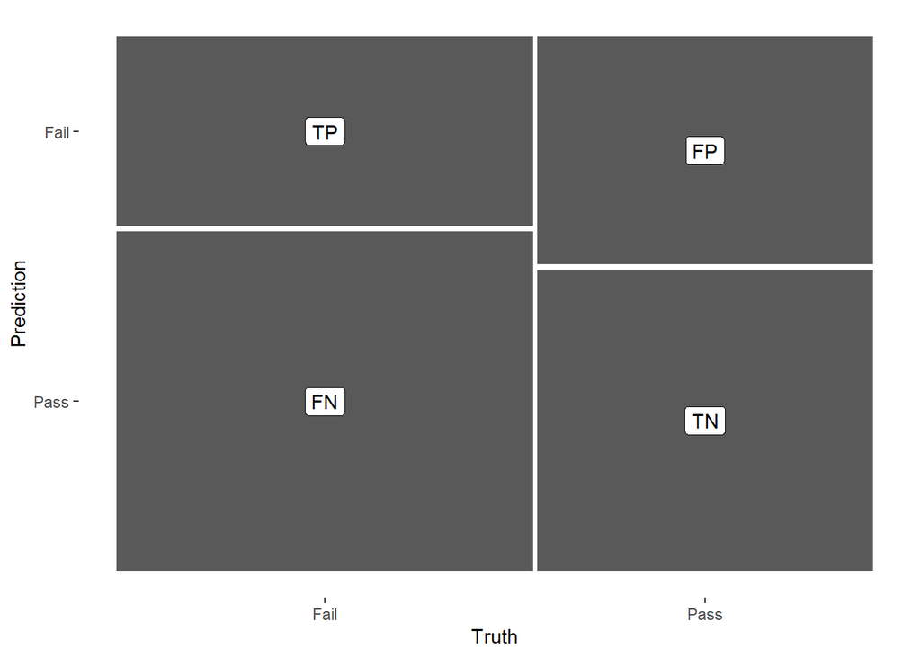

```r
log_pred %>%
  conf_mat(test, .pred_class) %>%
  autoplot(type = "mosaic") +
  geom_label(aes(
      x = (xmax + xmin) / 2,
      y = (ymax + ymin) / 2,
      label = c("TP", "FN", "FP", "TN")))
```

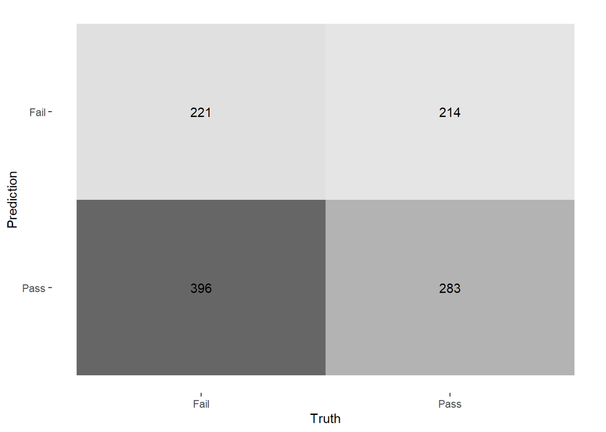

```r
log_pred %>%
  conf_mat(test, .pred_class) %>%
  autoplot(type = "heatmap")
```

```r
## ROC Curve

# log_pred %>%
#   group_by(id) %>% # id contains our folds
#   roc_curve(test, .pred_above) %>%
#   autoplot()
#
```

```r
## Decision Tree results

tree_res <-
  tree_wflow %>%
  fit_resamples(
    resamples = bechdel_folds,
    metrics = metric_set(
      recall, precision, f_meas,
      accuracy, kap,
      roc_auc, sens, spec),
    control = control_resamples(save_pred = TRUE)
    )

tree_res %>%  collect_metrics(summarize = TRUE)
```

```
## # A tibble: 8 × 6
##   .metric   .estimator  mean     n std_err .config
##   <chr>     <chr>      <dbl> <int>   <dbl> <chr>
## 1 accuracy  binary     0.584    10  0.0117 Preprocessor1_Model1
## 2 f_meas    binary     0.630    10  0.0103 Preprocessor1_Model1
## 3 kap       binary     0.155    10  0.0256 Preprocessor1_Model1
## 4 precision binary     0.623    10  0.0121 Preprocessor1_Model1
## 5 recall    binary     0.640    10  0.0177 Preprocessor1_Model1
## 6 roc_auc   binary     0.591    10  0.0160 Preprocessor1_Model1
## 7 sens      binary     0.640    10  0.0177 Preprocessor1_Model1
## 8 spec      binary     0.514    10  0.0304 Preprocessor1_Model1
```

```r
## Random Forest

rf_res <-
  rf_wflow %>%
  fit_resamples(
    resamples = bechdel_folds,
    metrics = metric_set(
      recall, precision, f_meas,
      accuracy, kap,
      roc_auc, sens, spec),
    control = control_resamples(save_pred = TRUE)
    )

rf_res %>%  collect_metrics(summarize = TRUE)
```

```
## # A tibble: 8 × 6
##   .metric   .estimator  mean     n std_err .config
##   <chr>     <chr>      <dbl> <int>   <dbl> <chr>
## 1 accuracy  binary     0.643    10  0.0150 Preprocessor1_Model1
## 2 f_meas    binary     0.708    10  0.0119 Preprocessor1_Model1
## 3 kap       binary     0.258    10  0.0317 Preprocessor1_Model1
## 4 precision binary     0.648    10  0.0126 Preprocessor1_Model1
## 5 recall    binary     0.781    10  0.0159 Preprocessor1_Model1
## 6 roc_auc   binary     0.667    10  0.0213 Preprocessor1_Model1
## 7 sens      binary     0.781    10  0.0159 Preprocessor1_Model1
## 8 spec      binary     0.470    10  0.0259 Preprocessor1_Model1
```

```r
## Boosted tree - XGBoost

xgb_res <-
  xgb_wflow %>%
  fit_resamples(
    resamples = bechdel_folds,
    metrics = metric_set(
      recall, precision, f_meas,
      accuracy, kap,
      roc_auc, sens, spec),
    control = control_resamples(save_pred = TRUE)
    )

xgb_res %>% collect_metrics(summarize = TRUE)
```

```
## # A tibble: 8 × 6
##   .metric   .estimator  mean     n std_err .config
##   <chr>     <chr>      <dbl> <int>   <dbl> <chr>
## 1 accuracy  binary     0.613    10  0.0128 Preprocessor1_Model1
## 2 f_meas    binary     0.661    10  0.0122 Preprocessor1_Model1
## 3 kap       binary     0.210    10  0.0271 Preprocessor1_Model1
## 4 precision binary     0.644    10  0.0137 Preprocessor1_Model1
## 5 recall    binary     0.686    10  0.0226 Preprocessor1_Model1
## 6 roc_auc   binary     0.648    10  0.0185 Preprocessor1_Model1
## 7 sens      binary     0.686    10  0.0226 Preprocessor1_Model1
## 8 spec      binary     0.523    10  0.0324 Preprocessor1_Model1
```

```r
library(kknn)
## K-nearest neighbour

knn_res <-
  knn_wflow %>%
  fit_resamples(
    resamples = bechdel_folds,
    metrics = metric_set(
      recall, precision, f_meas,
      accuracy, kap,
      roc_auc, sens, spec),
    control = control_resamples(save_pred = TRUE)
    )
```

```
## → A | warning: While computing binary `precision()`, no predicted events were detected (i.e. `true_positive + false_positive = 0`).
##                Precision is undefined in this case, and `NA` will be returned.
##                Note that 61 true event(s) actually occured for the problematic event level, 'Fail'.
```

[output not shown]

```r
knn_res %>% collect_metrics(summarize = TRUE)
```

```
## # A tibble: 8 × 6
##   .metric   .estimator     mean     n std_err .config
##   <chr>     <chr>         <dbl> <int>   <dbl> <chr>
## 1 accuracy  binary     0.543       10 0.0110  Preprocessor1_Model1
## 2 f_meas    binary     0.712        9 0.00136 Preprocessor1_Model1
## 3 kap       binary     0.000823    10 0.00424 Preprocessor1_Model1
## 4 precision binary     0.554        9 0.00102 Preprocessor1_Model1
## 5 recall    binary     0.897       10 0.0997  Preprocessor1_Model1
## 6 roc_auc   binary     0.541       10 0.0246  Preprocessor1_Model1
## 7 sens      binary     0.897       10 0.0997  Preprocessor1_Model1
## 8 spec      binary     0.104       10 0.0996  Preprocessor1_Model1
```

```r
## Model Comparison

log_metrics <-
  log_res %>%
  collect_metrics(summarise = TRUE) %>%
  # add the name of the model to every row
  mutate(model = "Logistic Regression")

tree_metrics <-
  tree_res %>%
  collect_metrics(summarise = TRUE) %>%
  mutate(model = "Decision Tree")

rf_metrics <-
  rf_res %>%
  collect_metrics(summarise = TRUE) %>%
  mutate(model = "Random Forest")

xgb_metrics <-
  xgb_res %>%
  collect_metrics(summarise = TRUE) %>%
  mutate(model = "XGBoost")

knn_metrics <-
  knn_res %>%
  collect_metrics(summarise = TRUE) %>%
  mutate(model = "Knn")
```

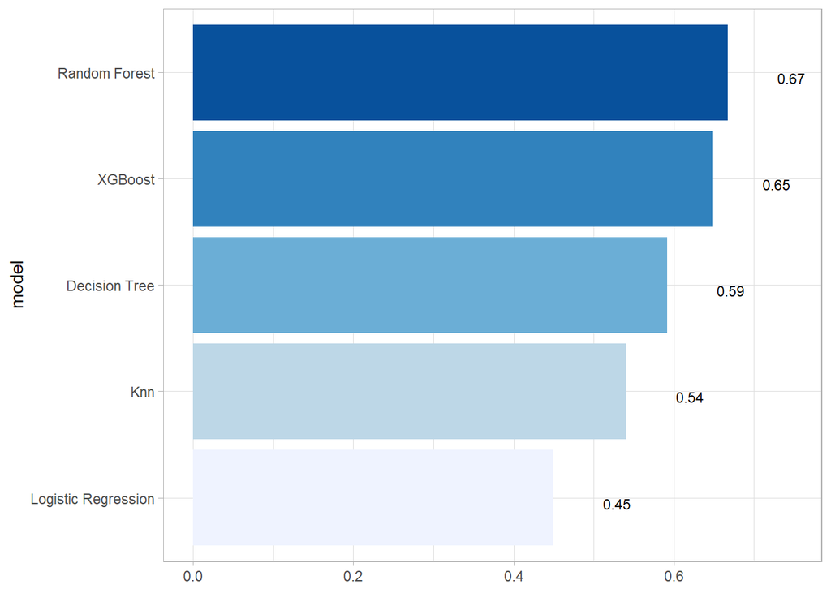

```r
# create dataframe with all models
model_compare <- bind_rows(log_metrics,
                           tree_metrics,
                           rf_metrics,
                           xgb_metrics,
                           knn_metrics)

#Pivot wider to create barplot
  model_comp <- model_compare %>%
  select(model, .metric, mean, std_err) %>%
  pivot_wider(names_from = .metric, values_from = c(mean, std_err))

# show mean are under the curve (ROC-AUC) for every model
model_comp %>%
  arrange(mean_roc_auc) %>%
  mutate(model = fct_reorder(model, mean_roc_auc)) %>% # order results
  ggplot(aes(model, mean_roc_auc, fill=model)) +
  geom_col() +
  coord_flip() +
  scale_fill_brewer(palette = "Blues") +
   geom_text(
     size = 3,
     aes(label = round(mean_roc_auc, 2),
         y = mean_roc_auc + 0.08),
     vjust = 1
  )+
  theme_light()+
  theme(legend.position = "none")+
  labs(y = NULL)
```

```r
## `last_fit()` on test set

# - `last_fit()`  fits a model to the whole training data and evaluates it on the test set.
# - provide the workflow object of the best model as well as the data split object (not the training data).

last_fit_xgb <- last_fit(xgb_wflow,
                        split = data_split,
                        metrics = metric_set(
                          accuracy, f_meas, kap, precision,
                          recall, roc_auc, sens, spec))

last_fit_xgb %>% collect_metrics(summarize = TRUE)
```

```
## # A tibble: 8 × 4
##   .metric   .estimator .estimate .config
##   <chr>     <chr>          <dbl> <chr>
## 1 accuracy  binary         0.579 Preprocessor1_Model1
## 2 f_meas    binary         0.642 Preprocessor1_Model1
## 3 kap       binary         0.134 Preprocessor1_Model1
## 4 precision binary         0.606 Preprocessor1_Model1
## 5 recall    binary         0.684 Preprocessor1_Model1
## 6 sens      binary         0.684 Preprocessor1_Model1
## 7 spec      binary         0.448 Preprocessor1_Model1
## 8 roc_auc   binary         0.598 Preprocessor1_Model1
```

```r
#Compare to training
xgb_res %>% collect_metrics(summarize = TRUE)
```

```
## # A tibble: 8 × 6
##   .metric   .estimator  mean     n std_err .config
##   <chr>     <chr>      <dbl> <int>   <dbl> <chr>
## 1 accuracy  binary     0.613    10  0.0128 Preprocessor1_Model1
## 2 f_meas    binary     0.661    10  0.0122 Preprocessor1_Model1
## 3 kap       binary     0.210    10  0.0271 Preprocessor1_Model1
## 4 precision binary     0.644    10  0.0137 Preprocessor1_Model1
## 5 recall    binary     0.686    10  0.0226 Preprocessor1_Model1
## 6 roc_auc   binary     0.648    10  0.0185 Preprocessor1_Model1
## 7 sens      binary     0.686    10  0.0226 Preprocessor1_Model1
## 8 spec      binary     0.523    10  0.0324 Preprocessor1_Model1
```

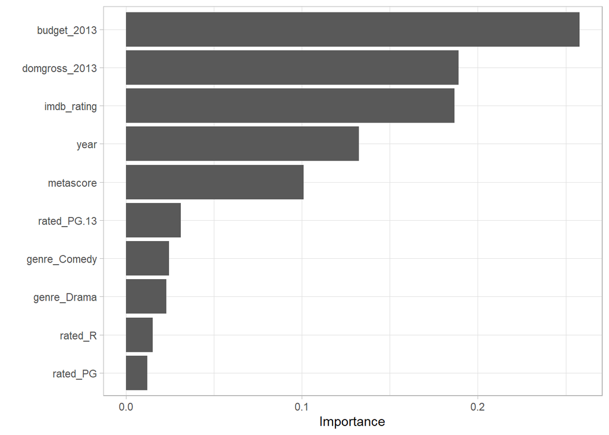

```r
## Variable importance using `{vip}` package

library(vip)

last_fit_xgb %>%
  pluck(".workflow", 1) %>%
  pull_workflow_fit() %>%
  vip(num_features = 10) +
  theme_light()
```

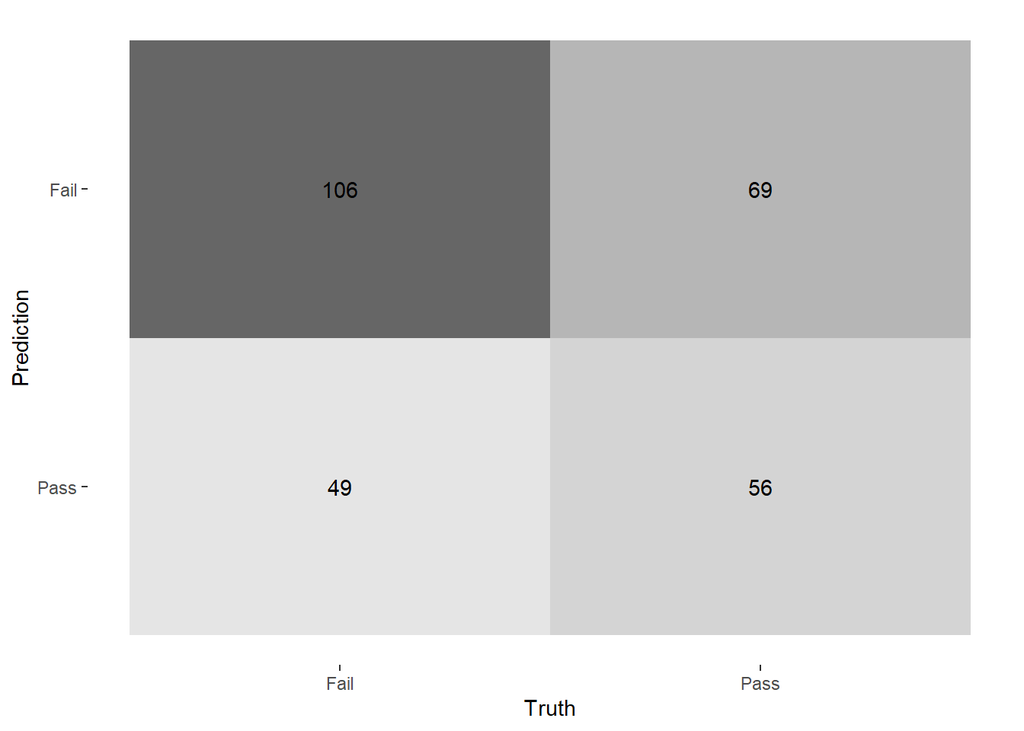

```r
## Final Confusion Matrix

last_fit_xgb %>%
  collect_predictions() %>%
  conf_mat(test, .pred_class) %>%
  autoplot(type = "heatmap")
```

```r
# library(yardstick)
# ## Final ROC curve
# last_fit_xgb %>%
#   collect_predictions() %>%
#   roc_curve(test, .pred_above) %>%
#   autoplot()
```

# 10 Deliverables

There is a lot of explanatory text, comments, etc. You do not need these, so delete them and produce a stand-alone document that you could share with someone. Knit the edited and completed R Markdown (Rmd) file as a Word or HTML document (use the “Knit” button at the top of the script editor window) and upload it to Canvas. You must be commiting and pushing your changes to your own Github repo as you go along.

# 11 Details

**Please seek out help when you need it,** and remember the [15-minute rule](https://dsb2023.netlify.app/syllabus/#the-15-minute-rule). You know enough R (and have enough examples of code from class and your readings) to be able to do this. If you get stuck, ask for help from others, post a question on Slack– and remember that I am here to help too!

> As a true test to yourself, do you understand the code you submitted and are you able to explain it to someone else?

# 12 Rubric

13/13: Problem set is 100% completed. Every question was attempted and answered, and most answers are correct. Code is well-documented (both self-documented and with additional comments as necessary). Used tidyverse, instead of base R. Graphs and tables are properly labelled. Analysis is clear and easy to follow, either because graphs are labeled clearly or you’ve written additional text to describe how you interpret the output. Multiple Github commits. Work is exceptional. I will not assign these often.

8/13: Problem set is 60–80% complete and most answers are correct. This is the expected level of performance. Solid effort. Hits all the elements. No clear mistakes. Easy to follow (both the code and the output). A few Github commits.

5/13: Problem set is less than 60% complete and/or most answers are incorrect. This indicates that you need to improve next time. I will hopefully not assign these often. Displays minimal effort. Doesn’t complete all components. Code is poorly written and not documented. Uses the same type of plot for each graph, or doesn’t use plots appropriate for the variables being analyzed. No Github commits.